# IODS week 3

## Glimpse to the data

Full information can be found in [here](https://archive.ics.uci.edu/ml/datasets/Student+Performance).

```
## Column names:
```

```
##  [1] "school"     "sex"        "age"        "address"    "famsize"
##  [6] "Pstatus"    "Medu"       "Fedu"       "Mjob"       "Fjob"
## [11] "reason"     "nursery"    "internet"   "guardian"   "traveltime"
## [16] "studytime"  "failures"   "schoolsup"  "famsup"     "paid"
## [21] "activities" "higher"     "romantic"   "famrel"     "freetime"
## [26] "goout"      "Dalc"       "Walc"       "health"     "absences"
## [31] "G1"         "G2"         "G3"         "alc_use"    "high_use"
```

The data set includes information about students’ performance participating in mathematics and Portuguese classes. As described in the website “*The data attributes include student grades, demographic, social and school related features and it was collected by using school reports and questionnaires. Two datasets are provided regarding the performance in two distinct subjects: Mathematics (mat) and Portuguese language (por).*”

The data has information of 382 individuals on 35 subjects. Of the respondents, 198 identified female and 184 male. And the mean age was 16.8 years.

## Studying relationships with alcohol consumption

I chose to model the alcohol consumption by explaining it with nursery school attendance, family size (famsize), relationships’ quality (famrel) and absences. I hypothesize that

- attending nursery school lowers alcohol use
- the bigger the family, the greater the chance for increased use of alcohol (because of non-existent or minor supervision from parents)
- better family relationships account for lower use of alcohol
- more absences are a clear indicator that something is wrong.

### Nursery

Let’s cross tabulate nursery and alcohol use and take columns’ proportional percentages:

Nursery / high use

|  | FALSE | TRUE |
| --- | --- | --- |
| no | 0.172 | 0.228 |
| yes | 0.828 | 0.772 |

We see that a slightly larger proportion of those not who had not attended nursery school are in fact “high users”. Upon conducting a $\chi^2$-test it was verified that the difference is not significant ($p \approx 0.25$).

### Family size

Let’s do a similar cross tabulation:

Family size / high use

|  | FALSE | TRUE |
| --- | --- | --- |
| GT3 | 0.75 | 0.675 |
| LE3 | 0.25 | 0.325 |

It is seen that the proportions are quite the same, though greater alcohol consumption seems to be associated with living in a smaller family.

### Quality of family’s relations

Lets plot the proportions:

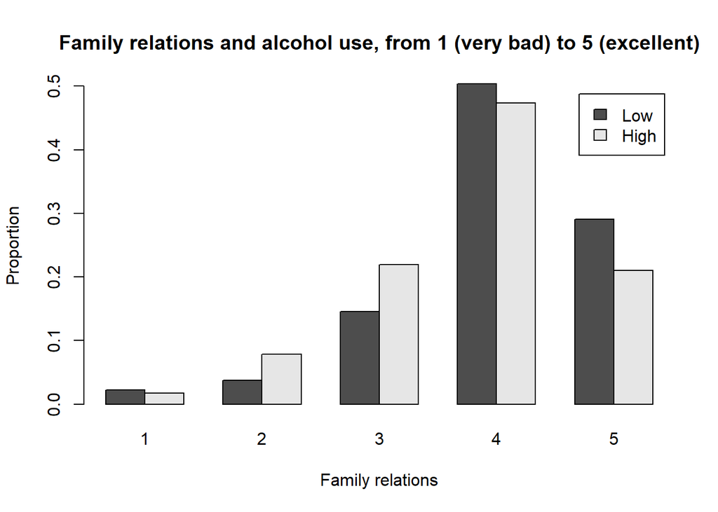

The bar plot supports our hypothesis, as high users seem to have worse family relations.

### Absences

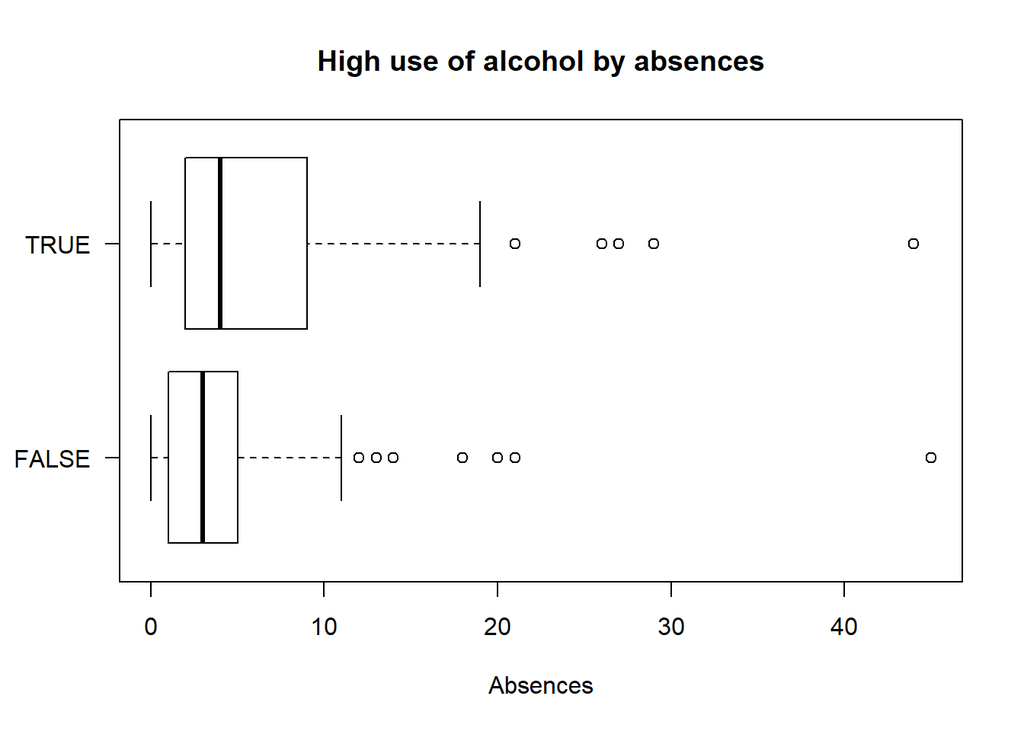

The plots – yet again – support our hypothesis, high users seem to have more absences from school.

## Logistic regression

Next we will fit logistic regression model explain reasons for alcohol’s high use.

```
##
## Call:
## glm(formula = high_use ~ nursery + famsize + famrel + absences,
##     family = "binomial", data = alc)
##
## Deviance Residuals:
##     Min       1Q   Median       3Q      Max
## -2.4516  -0.8364  -0.6850   1.1891   1.9524
##
## Coefficients:
##             Estimate Std. Error z value Pr(>|z|)
## (Intercept) -0.09520    0.55780  -0.171 0.864485
## nurseryyes  -0.46506    0.28932  -1.607 0.107967
## famsizeLE3   0.39087    0.25613   1.526 0.126991
## famrel      -0.23692    0.12408  -1.909 0.056211 .
## absences     0.08883    0.02320   3.830 0.000128 ***
## ---
## Signif. codes:  0 '***' 0.001 '**' 0.01 '*' 0.05 '.' 0.1 ' ' 1
##
## (Dispersion parameter for binomial family taken to be 1)
##
##     Null deviance: 465.68  on 381  degrees of freedom
## Residual deviance: 439.36  on 377  degrees of freedom
## AIC: 449.36
##
## Number of Fisher Scoring iterations: 4
```

As is seen from the above summary, the number of absences is associated significantly with the high use of alcohol. When absences increase, high use is more probable. The family relations’ quality is almost significant ($p \approx 0.056$). Let’s print the odds ratios:

Regression model estimates with 95% CI’s

|  | Coef | 2.5 % | 97.5 % |
| --- | --- | --- | --- |
| (Intercept) | 0.909 | 0.301 | 2.706 |
| nurseryyes | 0.628 | 0.358 | 1.117 |
| famsizeLE3 | 1.478 | 0.891 | 2.437 |
| famrel | 0.789 | 0.618 | 1.007 |
| absences | 1.093 | 1.046 | 1.146 |

In a statistical sense, the only inference that can be made is that absences affect alcohol use (or that they are associated, correlation doesn’t imply causality) which supports my original hypothesis. If we strictly look at the estimates, the nursery school attendance and family relations are in line with my original hypothesis. the effect of family size is not.

## Exploring the predictive power of my model

```
##                prediction
## high_use_actual FALSE TRUE
##           FALSE   258   10
##           TRUE     97   17
```

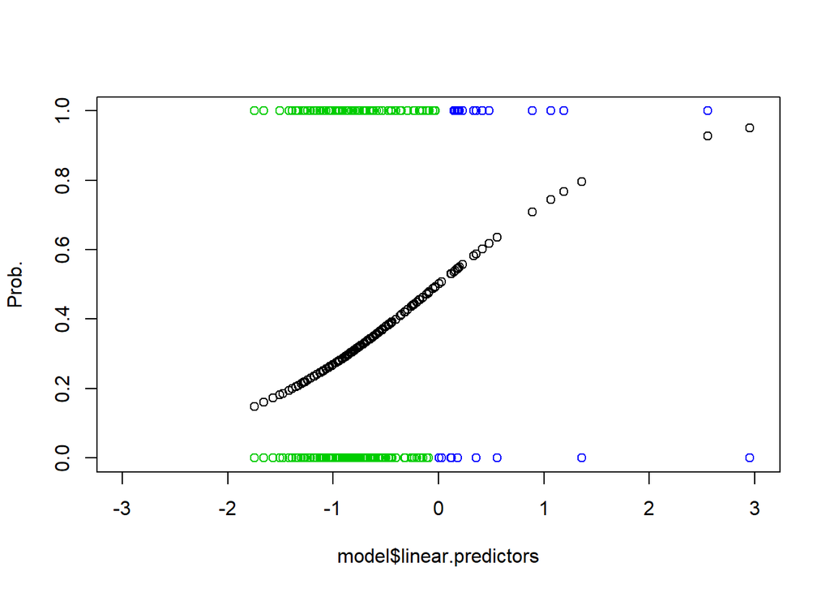

```
## Total proportion of inaccurately classified individuals:
```

```
## [1] 0.2801047
```

Comments:

- The model predicted the false ones quite well
- In the true ones there were some issues: of the 114 true high users, only 17 was correctly identified.
- If we would have just guessed the out comes by say, flipping a coin, we would have achieved significantly worse results. To confirm this, if we conducted a binomial test with parameters that we had $258+17=275$ successes in $258+10+97+17=382$ trials and that the underlying probability would have been 0.5, the test would have resulted in $p \leq 2.2\cdot10^{-16}$. Htis means that with a fair coin (or arbitrary guesses) there would have been no way to be even this accurate.

#### Cross validation

```
## [1] 0.2801047
```

```
## [1] 0.2853403
```

My model has around 28 percent error rate, so it is worse than the one in DataCamp, but usually better than the one given by the cross validation function.